# Homework-04

STAT 5732: Introduction to R for Data Science I

Author

Affiliation

Selin Kirbas

The Ohio State University

Published

April 4, 2025

# Exercises

## R4DS 25.2.5

### Exercise 1

#### Question

Practice turning the following code snippets into functions. Think about what each function does. What would you call it? How many arguments does it need?

```r
mean(is.na(x))
mean(is.na(y))
mean(is.na(z))

x / sum(x, na.rm = TRUE)
y / sum(y, na.rm = TRUE)
z / sum(z, na.rm = TRUE)

round(x / sum(x, na.rm = TRUE) * 100, 1)
round(y / sum(y, na.rm = TRUE) * 100, 1)
round(z / sum(z, na.rm = TRUE) * 100, 1)
```

#### Solution

```r
# Function to calculate proportion of NA values
prop_na <- function(x) {
  mean(is.na(x))
}

# Test
test_vector <- c(1, 2, NA, 4, NA)
prop_na(test_vector)
```

```
[1] 0.4
```

The first function calculates the proportion of missing values in a vector, so I would call it prop_na, & it needs one argument, which is the vector to analyze.

```r
# Function to normalize a vector
normalize <- function(x) {
  x / sum(x, na.rm = TRUE)
}

# Test
test_vector <- c(1, 2, 3, 4, NA)
normalize(test_vector)
```

```
[1] 0.1 0.2 0.3 0.4  NA
```

The second function normalizes values in a vector by dividing each element by the sum of all non-NA values, so I would call it normalize, & it needs one argument, which is the vector to normalize.

```r
# Function to calculate % of total with rounding
percent_of_total <- function(x, digits = 1) {
  round(x / sum(x, na.rm = TRUE) * 100, digits)
}

# Test
test_vector <- c(10, 20, 30, 40, NA)
percent_of_total(test_vector)
```

```
[1] 10 20 30 40 NA
```

The third function calculates each value as a percentage of the total, so I would all it percent_of_total & it needs one argument, which is the vector, and can also use another (optional) argument, which is digits for rounding.

### Exercise 2

#### Question

In the second variant of rescale01(), infinite values are left unchanged. Can you rewrite rescale01() so that -Inf is mapped to 0, and Inf is mapped to 1?

#### Solution

The original rescale01() function scales values to be between 0 and 1, so I’m going to make it so it can handle infinite values:

```r
# CHanged rescale01 function to handle infinite values
rescale01 <- function(x) {
  # Replace infinite values first
  x[x == -Inf] <- 0
  x[x == Inf] <- 1

  # Scale finite values
  rng <- range(x, na.rm = TRUE, finite = TRUE)
  (x - rng[1]) / (rng[2] - rng[1])
}

# Test
test_vector <- c(-Inf, 1, 2, 5, 10, Inf)
rescale01(test_vector)
```

```
[1] 0.0 0.1 0.2 0.5 1.0 0.1
```

### Exercise 5

#### Question

Write `both_na()`, a summary function that takes two vectors of the same length and returns the number of positions that have an NA in both vectors.

#### Solution

```r
both_na <- function(x, y) {
  # Check if vectors have same length
  if (length(x) != length(y)) {
    stop("Both vectors must have the same length")
  }

  # Count positions where both have NA
  sum(is.na(x) & is.na(y))
}

# Test
vector1 <- c(1, NA, 3, NA, 5)
vector2 <- c(NA, NA, 3, 4, NA)
both_na(vector1, vector2)
```

```
[1] 1
```

The function takes two vectors and returns the count of positions where both vectors have NA values. The function first checks if the vectors have the same length, then counts where both have NA.

## R4DS 25.3.5

### Exercise 1.4

#### Question

Using the datasets from nycflights13, write a function that:

Summarizes the weather to compute the minimum, mean, and maximum, of a user supplied variable:

```r
weather |> summarize_weather(temp)
```

#### Solution

```r
# Function to summarize weather data
summarize_weather <- function(data, var) {
  data |>
    summarize(
      min = min({{ var }}, na.rm = TRUE),
      mean = mean({{ var }}, na.rm = TRUE),
      max = max({{ var }}, na.rm = TRUE)
    )
}

# Example
weather |> summarize_weather(humid)
```

```
# A tibble: 1 × 3
    min  mean   max
  <dbl> <dbl> <dbl>
1  12.7  62.5   100
```

The function uses tidy evaluation to summarize a user supplied variable from the weather dataset. It calculates the min, mean, and max values of the variable while also handling missing values.

### Exercise 2

#### Question

For each of the following functions list all arguments that use tidy evaluation and describe whether they use data-masking or tidy-selection: `distinct()`, `count()`, `group_by()`, `rename_with()`, `slice_min()`, `slice_sample()`.

#### Solution

1. **distinct()**
   - Arguments using tidy evaluation: `...`
   - Type: Data-masking (uses column values from the data frame)
2. **count()**
   - Arguments using tidy evaluation: `...`
   - Type: Data-masking (uses column values from the data frame)
3. **group_by()**
   - Arguments using tidy evaluation: `...`
   - Type: Data-masking (uses column values from the data frame)
4. **rename_with()**
   - Arguments using tidy evaluation: `.cols`
   - Type: Tidy-selection (uses column names/positions)
5. **slice_min()**
   - Arguments using tidy evaluation: `order_by`
   - Type: Data-masking (uses column values from the data frame)
6. **slice_sample()**
   - Arguments using tidy evaluation: `weight_by`
   - Type: Data-masking (uses column values from the data frame)

## R4DS 25.4.4

### Question

Build up a rich plotting function by incrementally implementing each of the steps below:

1. Draw a scatterplot given dataset and x and y variables.
2. Add a line of best fit (i.e. a linear model with no standard errors).
3. Add a title.

### Solution

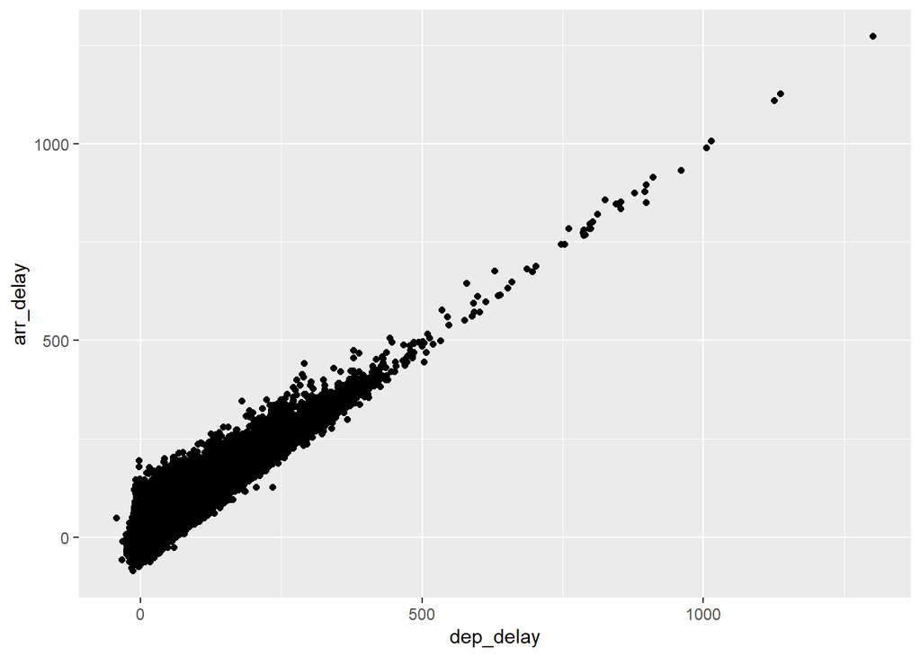

```r
# Basic scatterplot function
plot_scatter_basic <- function(data, x_var, y_var) {
  ggplot(data, aes(x = {{ x_var }}, y = {{ y_var }})) +
    geom_point()
}

# Show function
plot_scatter_basic(flights, dep_delay, arr_delay)
```

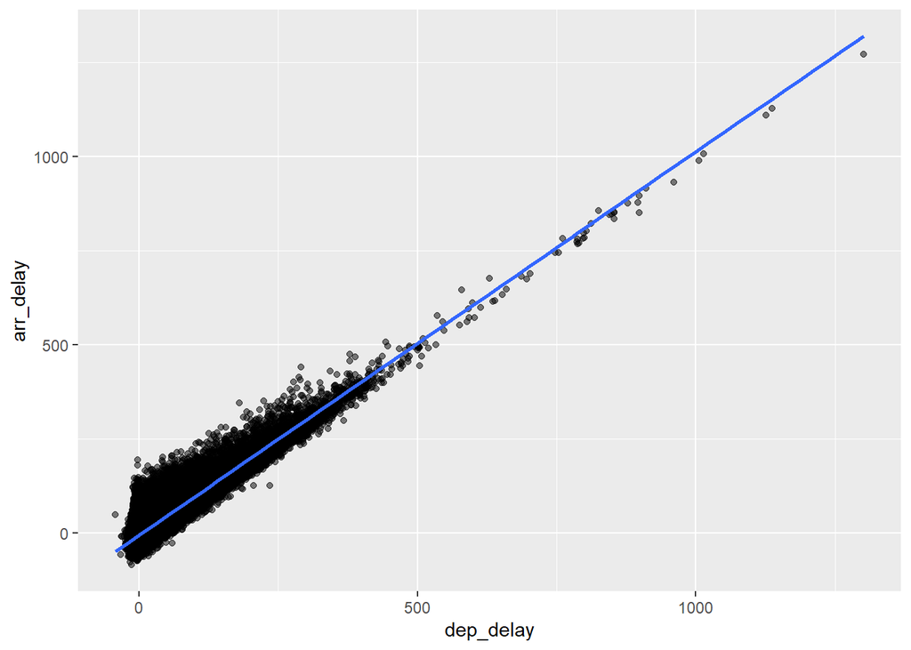

```r
# Add line of best fit
plot_scatter_with_trend <- function(data, x_var, y_var) {
  ggplot(data, aes(x = {{ x_var }}, y = {{ y_var }})) +
    geom_point(alpha = 0.5) +
    geom_smooth(method = "lm", se = FALSE)
}

# Show with trend line
plot_scatter_with_trend(flights, dep_delay, arr_delay)
```

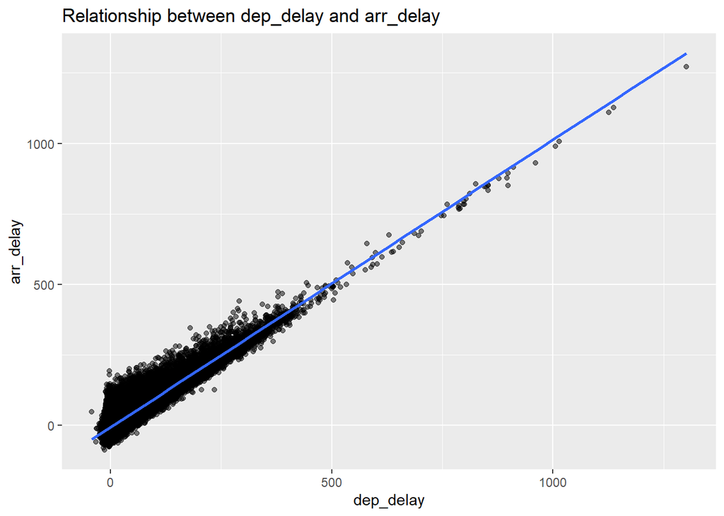

```r
# Function with title
plot_scatter <- function(data, x_var, y_var, title = NULL) {
  # Create default title if none provided
  if (is.null(title)) {
    x_name <- rlang::as_name(rlang::enquo(x_var))
    y_name <- rlang::as_name(rlang::enquo(y_var))
    title <- paste("Relationship between", x_name, "and", y_name)
  }

  ggplot(data, aes(x = {{ x_var }}, y = {{ y_var }})) +
    geom_point(alpha = 0.5) +
    geom_smooth(method = "lm", se = FALSE) +
    labs(title = title)
}

# Final function with default title
plot_scatter(flights, dep_delay, arr_delay)
```